# MATH1324 Assignment 2

Modeling Body Measurements

## Student Details

Student Name: Alistair Grevis-James Student Number: s3644119 s3644119@student.rmit.edu.au

## Executive Summary

The packages ggplot2 & dplyr were imported into the R-Studio Interactive Environment (Version 1.0.143 – © 2009-2016 RStudio, Inc.). The file “bdims.csv” was imported into R-Studio as “bdims”. The importation was checked showing a size of 507 observations by 25 variables. No missing data was found. Summary statistics for all, male and female were determined. Visualization was performed with histograms, which were overlayed with normal curves.

## Problem Statement

After importation of the data set “bdims.csv”, summary statistics will be determined for the variable ‘bic.gi’. This variable is described as “respondent’s bicep girth in centimeters, measured when flexed as the average of right and left girths”. Of the 507 observations, 247 originate from males (denoted ‘1’) & 260 from females (denoted ‘0’). Summary statistics will enable us to determine if there is a quantifiable difference for measurements of ‘bic.gi’ from the sample set. Data visualization (using histograms) will allow us to better interpret such difference. Normal curve overlay will allow us to determine if the empirical data has a normal distribution.

## Load Packages & Data Importation

```r
library(ggplot2)
library(dplyr)
setwd("/Users/alistairgj/R Scripts")
getwd()
bdims <- read.csv("bdims.csv")
```

## Data Checking

The internal structure of the data was first checked with str(). This showed the data was in the form ‘data.frame’ with 507 observations of 25 variables. Data types consist of num and int. The categories male (m) and female (f) has been given the int values 1 and 0, respectively.

```r
str(bdims)
```

[output not shown]

Confirming rows 1 till 247 are males (1), while rows 248 till 507 are female (0).

```r
bdims$sex[c(1,247,248,507)]
table(bdims$sex[1:247])
table(bdims$sex[248:507])
```

[output not shown]

## Summary Statistics

##### Mean (All, Male, Female)

```r
mean(bdims$bic.gi)
mean(bdims$bic.gi[1:247])
mean(bdims$bic.gi[248:507])
```

[output not shown]

##### Range (All, Male, Female) - Gives min and max

```r
range(bdims$bic.gi)
range(bdims$bic.gi[1:247])
range(bdims$bic.gi[248:507])
```

[output not shown]

##### Varience (All, Male, Female)

```r
var(bdims$bic.gi)
var(bdims$bic.gi[1:247])
var(bdims$bic.gi[248:507])
```

[output not shown]

##### Standard Deviation (All, Male, Female)

```r
sd(bdims$bic.gi)
sd(bdims$bic.gi[1:247])
sd(bdims$bic.gi[248:507])
```

[output not shown]

##### Quartile (All, Male, Female)

```r
quantile(bdims$bic.gi)
quantile(bdims$bic.gi[1:247])
quantile(bdims$bic.gi[248:507])
```

[output not shown]

##### IQR (All, Male, Female)

```r
IQR(bdims$bic.gi)
```

```
[1] 6.85
```

```r
IQR(bdims$bic.gi[1:247])
```

```
[1] 3.9
```

```r
IQR(bdims$bic.gi[248:507])
```

```
[1] 3.4
```

##### Median (All, Male, Female)

```r
median(bdims$bic.gi)
median(bdims$bic.gi[1:247])
median(bdims$bic.gi[248:507])
```

[output not shown]

##### Grouping

[output not shown]

## Distribution Fitting

##### Histogram (All) without considering bins

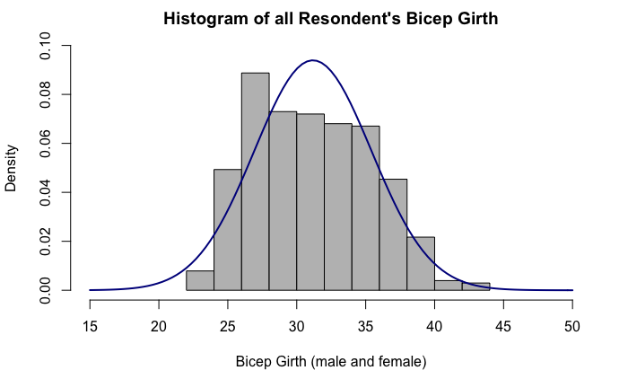

##### Bins (All)

```r
sqrt(507)
```

```
[1] 22.51666
```

##### Histogram (All) with 23 bins

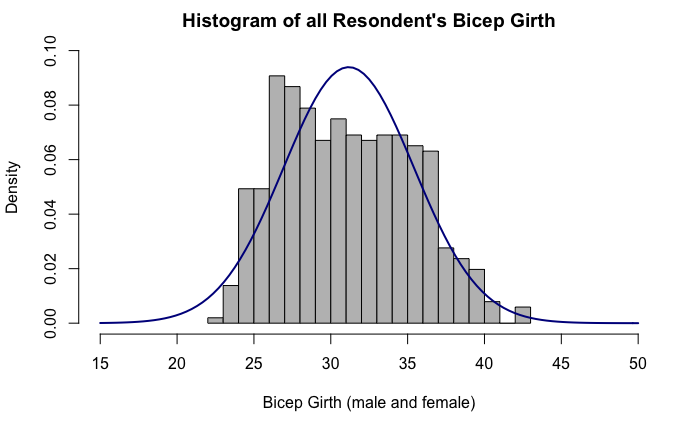

##### Histogram (Male) without considering bins

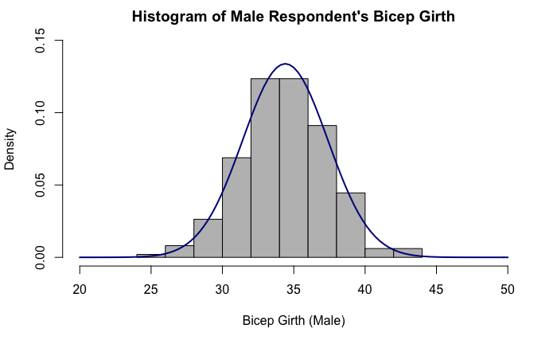

##### Bins (Male)

```r
sqrt(247)
```

[output not shown]

##### Histogram (Male) with 16 bins

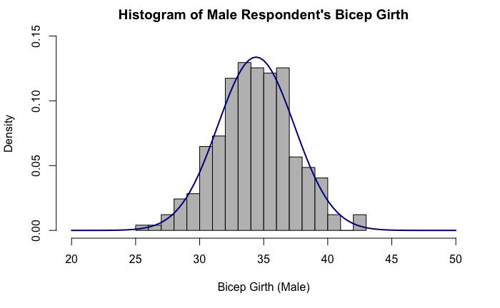

##### Histogram (Female) without considering bins

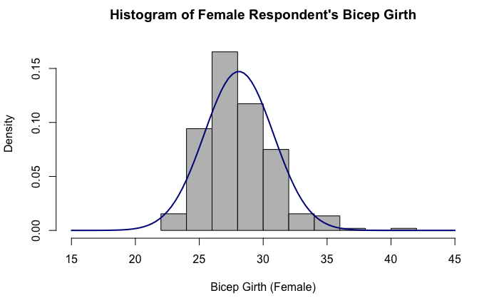

##### Bins (Female)

```r
sqrt(260)
```

[output not shown]

##### Histogram (Female) with 16 bins

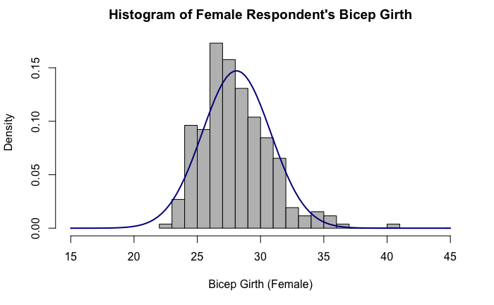

## Interpretation

Throughout this investigation we have developed our statistical data processing skills through analysis of the variable ‘bic.gi’ (respondent’s bicep girth in centimeters, measured when flexed as the average of right and left girths). Statistics summary enabled us to quantify and record the different statistical properties (mean, sd, median, e.t.c.,) between male, female and all participants.

The processing and resultant visualization shows that for the variable bic.gi, splitting the respondent’s into male and female gives a more meaningfull statistical result.

Direction for future study includes more statistical evaluation / visualization (e.g., box plots), and comparative analysis using additional variables (age, height, and so on). Strong correlations between various body dimensions may also exist, and determining these may eliminate the need certain measurements.